# Βασικές Αλγεβρικές Δομές

439 Υπολογιστική Άλγεβρα — Κεφάλαιο 2

Ζαφειράκης Ζαφειρακόπουλος

2026-08-10

## Ατζέντα

- Δακτύλιοι, Σώματα, Ακέραιες Περιοχές
- Ο δακτύλιος πολυωνύμων $K[x]$
- Ευκλείδεια διαίρεση και Ευκλείδειες περιοχές

# Δακτύλιοι, Σώματα, Ακέραιες Περιοχές

## Ορισμός (Δακτύλιος)

Ένας **δακτύλιος** $(R,+,\cdot)$: σύνολο με δύο πράξεις τέτοιες ώστε

1. $(R,+)$ αβελιανή ομάδα, με $0$
2. η $\cdot$ προσεταιριστική
3. επιμεριστικοί νόμοι: $a(b+c)=ab+ac$, $(a+b)c=ac+bc$

**Σύμβαση μαθήματος:** κάθε δακτύλιος αντιμεταθετικός με $1 \neq 0$ (όπως και το OSCAR).

## Ορισμός (Σώμα)

Ένα **σώμα** είναι αντιμεταθετικός δακτύλιος $K$ με $1 \neq 0$ όπου κάθε μη μηδενικό στοιχείο είναι αντιστρέψιμο:

$$\forall a \in K \setminus \{0\}\ \exists\, a^{-1} \in K:\ a\,a^{-1}=1.$$

## Ορισμός (Διαιρέτης του μηδενός, Ακέραια Περιοχή)

$a \neq 0$ είναι **διαιρέτης του μηδενός** αν $\exists\, b\neq 0$ με $ab=0$.

$R$ είναι **ακέραια περιοχή** αν $1\neq 0$ και δεν έχει διαιρέτες του μηδενός:
$$ab=0 \implies a=0 \text{ ή } b=0.$$

## Θεώρημα

1. Κάθε σώμα είναι ακέραια περιοχή.
2. Κάθε **πεπερασμένη** ακέραια περιοχή είναι σώμα.

**Παραδείγματα.** $\mathbb{Z}$: ακέραια περιοχή, όχι σώμα. $\mathbb{Q},\mathbb{R},\mathbb{C}$: σώματα. $\mathbb{Z}/n\mathbb{Z}$: σώμα $\iff$ $n$ πρώτος.

## Στο OSCAR

```
Integer ring
```

```
Rational field
```

$2$

## Παράδειγμα: $\mathbb{Z}/6\mathbb{Z}$ δεν είναι ακέραια περιοχή

αφού $2 \cdot 3 = 0$ ενώ $2,3 \neq 0$:

$0$

Για πρώτο modulo, π.χ. $\mathbb{Z}/7\mathbb{Z}$: σώμα, κάθε μη μηδενικό αντιστρέψιμο:

$5$

## Αντιστρέψιμα vs. διαιρέτες του μηδενός

Σε πεπερασμένο αντιμεταθετικό δακτύλιο με μονάδα: κάθε μη μηδενικό στοιχείο είτε αντιστρέψιμο είτε διαιρέτης του μηδενός.

```
([1, 5, 7, 11, 13, 17, 19, 23], [2, 3, 4, 6, 8, 9, 10, 12, 14, 15, 16, 18, 20, 21, 22])
```

$\mathbb{Z}/24\mathbb{Z}$: ούτε ακέραια περιοχή ούτε σώμα.

# Ο δακτύλιος πολυωνύμων $K[x]$

## Ορισμός (Δακτύλιος πολυωνύμων μιας μεταβλητής)

$K[x]$: ακολουθίες $(a_0,a_1,\dots)$, $a_i \in K$, **τελικά μηδενικές**, με

$$(a_i)+(b_i)=(a_i+b_i), \qquad (a_i)*(b_i)=(c_i),\ c_i=\sum_{j=0}^i a_j b_{i-j}.$$

Ο $*$ λέγεται **γινόμενο Cauchy** (convolution). Με $x=(0,1,0,\dots)$ ταυτίζεται με το γνωστό πολυώνυμο.

## Στο OSCAR

```
(3, 3)
```

## Θεώρημα (Ευκλείδεια διαίρεση στο $K[x]$)

Για $f,g \in K[x]$, $g\neq 0$, υπάρχουν **μοναδικά** $q,r \in K[x]$:

$$f = qg + r, \qquad r=0 \text{ ή } \deg(r)<\deg(g).$$

```
(3*x - 1, 11*x - 1)
```

## Ορισμός (Ευκλείδεια Περιοχή)

Ακέραια περιοχή $R$ με συνάρτηση βαθμού $\delta: R\setminus\{0\}\to\mathbb{N}$:

1. $\forall a,b\in R,\ b\neq 0$: $a=bq+r$, $r=0$ ή $\delta(r)<\delta(b)$
2. $\delta(a) \le \delta(ab)$

$\mathbb{Z}$ (με $\delta=|\cdot|$) και $K[x]$ (με $\delta=\deg$): Ευκλείδειες περιοχές.

## Η ιεραρχία

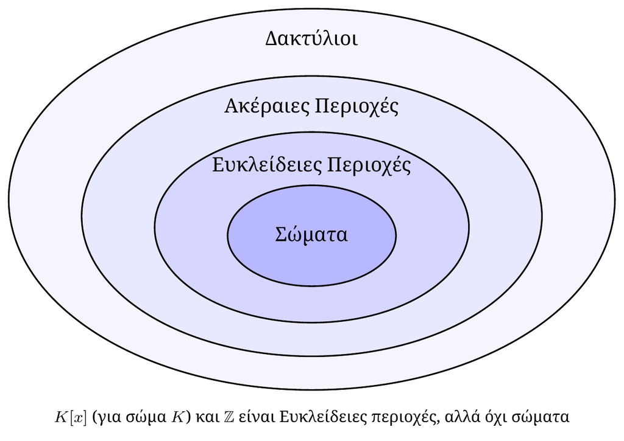

## GCD πολλών πολυωνύμων

$K[x]$ Ευκλείδεια περιοχή $\implies$ $\gcd$ πολλών πολυωνύμων ανά ζεύγη:

$x^{2} + x + 1$

## Σύνοψη

- Δακτύλιος, σώμα, ακέραια περιοχή, Ευκλείδεια περιοχή: η ιεραρχία δομών πάνω στην οποία χτίζεται όλο το μάθημα.
- Το $K[x]$ είναι Ευκλείδεια περιοχή — η βάση για όλη τη μονομεταβλητή θεωρία που ακολουθεί.
- Σύμβαση του μαθήματος: κάθε δακτύλιος αντιμεταθετικός με μοναδιαίο στοιχείο $1 \neq 0$, όπως και στο OSCAR.